# Final Project

Quan Gan, Yuxuan chen

11/27/2021

# H-1B LCA petitions analysis from 2016 to 2020

## Introduction

Non-US nationals who wish to work in the United States must first get valid visas. The H-1B visa is a non-immigrant visa that permits a foreign citizen to work in the United States in a specialty vocation. This is practically the only approach that international students could settle in the United States. The US employers will fill petitions on behalf of the high skilled foreign employees to apply for the H-1B visas. LCA refers to Labor Condition Application, which is the first process of H-1B applications. LCA is essential for ensuring that you are paid properly as a foreign worker and that you are not exploited by US companies. H-1B applications are approved by draw but LCA are approved primarily by Wage that must be higher than the same level US employees’ minimum wage. In this project, I’m investigating at what factors impact the approval of an H-1B LCA application. we wish US companies could reference this research to recruit high skills workers and help them gain H-1B and also the foreign job seekers or international students could follow this research to find qualified US companies. The larger questions the project addresses are how vocations’ needs evolve in the US market. The wage change and number of applications reflect the market’s needs in the United States. The study will reveal what factors contribute to the denial of LCA applications and which jobs are most likely to be approved.The significance of this research is that it may represent the challenges of acquiring a work permit in the United States as well as trends in the US market. The project’s societal problems are that it will affect international students’ or foreign job seekers’ decisions about whether or not to study or settle in the United States. Furthermore, the project will affect the US companies about whether or not to hire foreign employees. We’ll emphasize on data science-related professions like data scientist and data analyst after analyzing the total LCA applications.

### Research Question

> What factors impact the approval of LCA applications?

> What companies have high expectations of international workers?

> What are the changes of data science jobs; demands in the US market?

## Data

The data is extracted from non-immigrant and immigrant application tables within the office of foreign labor certification’s case management systems. The U.S. DEPARTMENT OF LABOR publishes the disclosure data on their website. https://www.dol.gov/agencies/eta/foreign-labor/performance. The data set is LCA Programs (H-1B, H-1B1, E-3). It contains LCA applications xlsx files from 2016 fiscal year to 2020 fiscal year. For the 2020 fiscal year, there are four xlsx files so in the later data wrangling, We need to merge them into one table. Every year, the number of variables grows. There are 41 variables in 2016, but there are 95 variables in 2020. Furthermore, the names of the variables differ. As a result, We’ll use variables that are present in all fiscal years and have the same meaning.

```r
# read data in
LCA_application <- read_csv("Data/LCA_cleaned.csv")
```

### Curation Rationale

The purpose of this data is to investigate the factors that influence the approval of H1B LCA applications, the companies that anticipate to recruit more foreign workers, and the trajectory of data science positions in the US market between 2016 and 2020. Each original data set contains unique records identifiable by the appropriate OFLC case number based on the most recent date a case determination judgment was made for the fiscal year. Furthermore, the data set is massive and imbalanced. The cleaned data set contains 3004616 records, yet only 1% of applications were declined. The H1-B type is the only one included in the LCA applications, and wage rates are uniform in year unit. 20% of the entries in the original data set had no full time position values. In order to deal with those missing values, we analyzed 75% percentile value for part-time positions and select 87000 as the cut-off. The cleaned columns’ names display below.

```r
colnames(LCA_application) %>%
  kable()
```

| x |
| --- |
| …1 |
| case_number |
| case_status |
| employer_name |
| visa_class |
| soc_name |
| job_title |
| full_time_position |
| worksite_city |
| worksite_state |
| year |
| wage_rate_from_year |
| wage_rate_to_year |
| prevailing_wage_year |
| submited_year |
| submited_month |
| submited_week |

### Participant Demographic

Because of policies, the public disclosure data set does not contain personally identifiable information. Therefore, there are no direct demographic information regarding age, gender, or race and ethnicity information but the data set contains the potential annual wage and employer name and work site information. We can guarantee that all of the participants are international employees from other nations other than the United States and there are certain companies in the United States who are interested in hiring them.

### Annotator Demographic

Based on petition information, the data is labeled as certified and denied.. There is no direct demographic characteristics of the annotators but the official policies and regulations provide guidance about the approval. The U.S. Citizenship and Immigration Services website (https://www.uscis.gov/working-in-the-united-states/h-1b-specialty-occupations.) also demonstrate the LCA requirements.

1. The employer/agent will pay the H-1B worker a wage which is no less than the wage paid to similarly qualified workers or, if greater, the prevailing wage for the position in the geographic area in which the H-1B worker will be working.
2. The employer/agent will provide working conditions that will not adversely affect other similarly employed workers.
3. At the time of the labor condition application there is no strike or lockout at the place of employment.
4. Notice of the filing of the labor condition application with the DOL has been given to the union bargaining representative or has been posted at the place of employment.

### Data Collection Situation

Records from the fiscal years 2016 through 2020 are included in the data set. The fiscal year runs from October 1 of the previous year to September 30 of the current year. For example, the fiscal year 2020 contains records from October 1, 2019 through September 30, 2020. The data is extracted from nonimmigrant and immigrant application tables within the Office of Foreign Labor Certification’s case management systems. The data is annotated by the faculties in Office of Foreign Labor certification of Department of Labor.

## Data Visualization

### Visualization One

> Question: What companies have high expectations of international workers arcoss years?

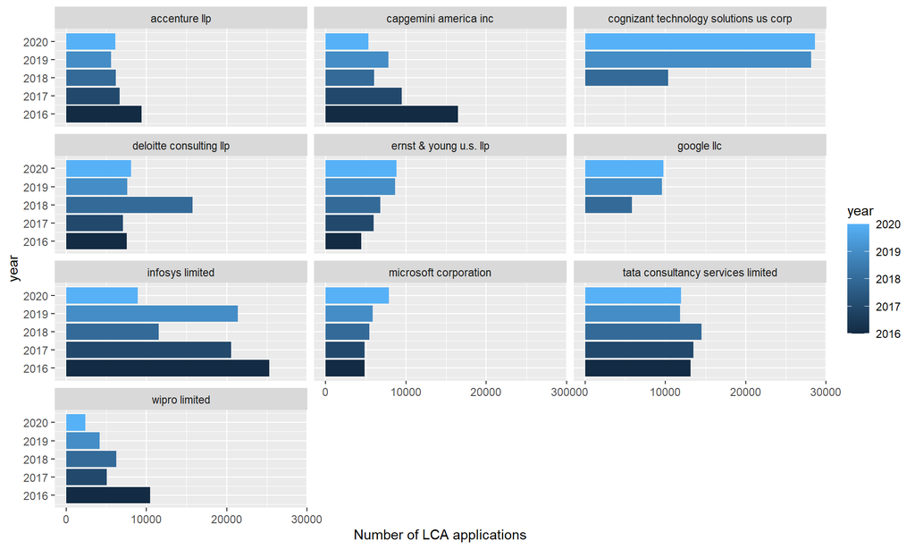

```r
# Find the top 10 companies that have most LCA applications.
top_10_company <- LCA_application %>%
  select(employer_name) %>%
  add_count(employer_name) %>%
  arrange(desc(n)) %>%
  unique() %>%
  top_n(10)

# Count the LCA applications of top 10 companies across years
company_application_number <- LCA_application %>%
  filter(employer_name %in% top_10_company$employer_name) %>%
  select(employer_name, year) %>%
  group_by(year) %>%
  add_count(employer_name) %>%
  arrange(year, desc(n)) %>%
  unique()

#Visualizing
company_application_number %>%
  group_by(employer_name, year) %>%
  ggplot(aes(x = year,
             y = n,
             fill = year)) +
  geom_col(position = "dodge") +
  facet_wrap(~employer_name, ncol = 3) +
  coord_flip() +
  labs(y = "Number of LCA applications") +
  scale_color_colorblind()
```

### Visualization Two

> Question: Would the prevailing wage rate and paid wage rate influence the approval of LCA application?

In LCA, the prevailing wage is defined as “the average wage paid to similarly employed workers in the requested occupation in the area of intended employment” from https://www.usavisanow.com/h-1b-visa/h1b-visa-resources/prevailing-wage/.

The paid wage rate is the actually wage paid to the foreign employee.

```r
# count case_status
LCA_application %>% count(case_status) %>%
  kable()
```

| case_status | n |
| --- | --- |
| certified | 2972793 |
| denied | 31823 |

```r
# set seed
set.seed(1)

# sample records from dataset
certified <- LCA_application %>%
  filter(case_status == "certified") %>%
  sample_n(10000)

denied <- LCA_application %>%
  filter(case_status == "denied") %>%
  sample_n(10000)


LCA_sample <- rbind(certified, denied)

# The wage_rate_from_year is the minimum paid wage rate and wage_rate_to_year is the
# maximum paid wage rate. So, we need to calculate the mean wage rate.
LCA_sample <- LCA_sample %>%
  mutate(mean_wage_rate_year = ifelse(wage_rate_to_year == 0,
                                      wage_rate_from_year,
                                      (wage_rate_from_year + wage_rate_to_year)/2))

LCA_sample <- LCA_sample %>%
  mutate(difference_prevailing_wage = mean_wage_rate_year - prevailing_wage_year)
```

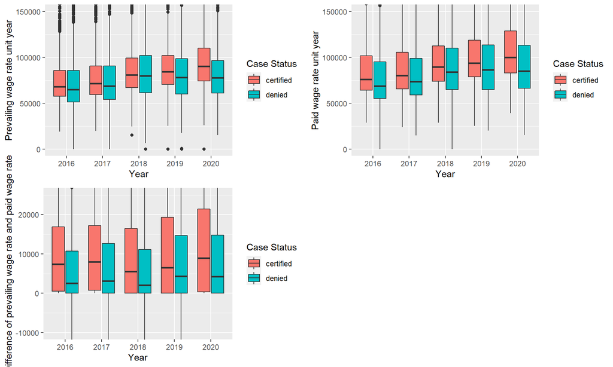

```r
LCA_sample %>%
  group_by(case_status) %>%
  ggplot(aes(x = factor(year),
             y = prevailing_wage_year,
             fill = case_status)) +
  geom_boxplot() +
  coord_cartesian(ylim=c(0,150000)) +
  labs(x = "Year",
       y = "Prevailing wage rate unit year",
       fill = "Case Status") +
  scale_color_colorblind() -> prevailing_plot_1

LCA_sample %>%
  group_by(case_status) %>%
  ggplot(aes(x = factor(year),
             y = mean_wage_rate_year,
             fill = case_status)) +
  geom_boxplot() +
  coord_cartesian(ylim=c(0,150000))+
  labs(x = "Year",
       y = "Paid wage rate unit year",
       fill = "Case Status") -> mean_wage_plot_1

LCA_sample %>%
  group_by(case_status) %>%
  ggplot(aes(x = factor(year),
             y = difference_prevailing_wage,
             fill = case_status)) +
  geom_boxplot() +
  coord_cartesian(ylim=c(-10000,25000))+
  labs(x = "Year",
       y = "Difference of prevailing wage rate and paid wage rate",
       fill = "Case Status") -> different_prevailing_plot_1

grid.arrange(prevailing_plot_1, mean_wage_plot_1, different_prevailing_plot_1, ncol = 2)
```

The means of prevailing wage rate and paid wage rate of refused LCA applications are lower than the means of certified LCA applications, as seen in the first two box plots. The mean gap between paid and prevailing pay rates is greater than the mean difference between paid and prevailing wage rates. The third box plots shows that the applicants receive the denied results because the employers don’t pay enough wage rate comparing to the prevailing wage rate. In addition, some paid wage rates of denied applications are less than the prevailing wage rate but certified applications always provide wage rate larger than prevailing wage. In the data, there are some extreme high wage rates, which are noise. In order to help the users understand the visualization better, I change the y-axis so the audiences could focus on the mean values.

### Visualization Three

> Question: What is the trends of data science related jobs?

In this question, we will analyze four popular data science related jobs, machine learning, data scientist, data engineer, and data analyst. How would their demand change? How would their wage rate change?

```r
# filter original data set and select data science related jobs.
ds_occupation <- c("machine learning", "data scientist", "data engineer", "data analyst")

LCA_application <- LCA_application %>%
  mutate(occupation = case_when(grepl("machine learning", job_title, fixed = TRUE) ~ "machine learning",
                                grepl("data scientist", job_title, fixed = TRUE) ~ "data scientist",
                                grepl("data engineer", job_title, fixed = TRUE) ~ "data engineer",
                                grepl("data analyst", job_title, fixed = TRUE) ~ "data analyst",
                                TRUE ~ job_title))

LCA_application %>%
  filter(occupation %in% ds_occupation) %>%
  count(occupation) %>%
  kable()
```

| occupation | n |
| --- | --- |
| data analyst | 17861 |
| data engineer | 12113 |
| data scientist | 16835 |
| machine learning | 2886 |

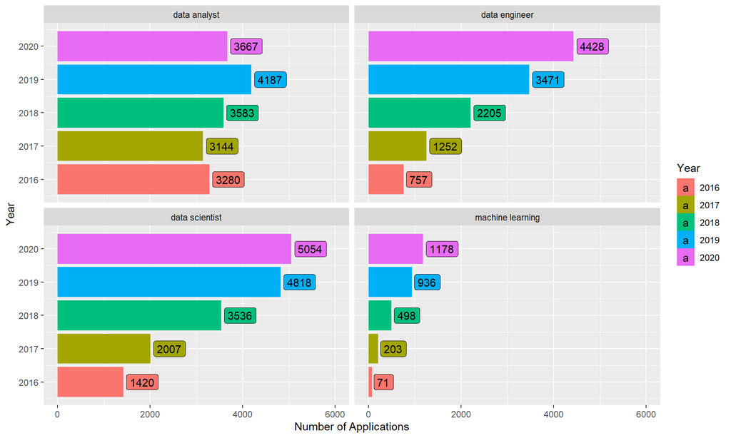

```r
# Visualizing LCA applications amount of data science jobs.
LCA_application %>%
  filter(occupation %in% ds_occupation) %>%
  group_by(occupation) %>%
  ggplot(aes(x = year, fill = factor(year))) +
  geom_bar(stat="count", position = "dodge") +
  geom_label(stat='count', aes(label=..count..), hjust = -0.1) +
  scale_y_continuous(limits=c(0, 6000)) +
  scale_color_colorblind() +
  coord_flip() +
  facet_wrap(~occupation) +
  labs(x = "Year",
       y = "Number of Applications",
       fill = "Year")
```

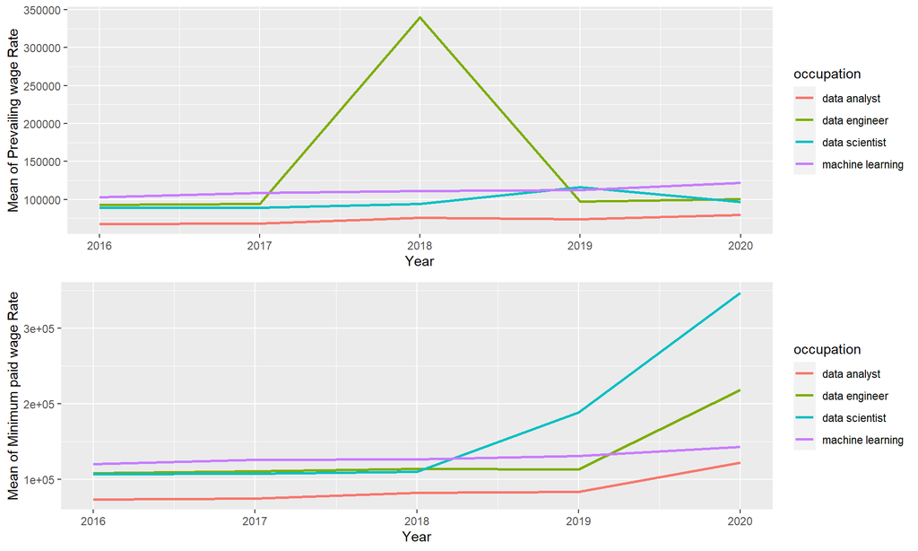

```r
# Visualizing the prevailing wage rage of data science job
LCA_application %>%
  filter(occupation %in% ds_occupation) %>%
  group_by(occupation, year) %>%
  summarise(mean_wage = mean(prevailing_wage_year)) %>%
  ggplot(aes(x = year, y = mean_wage, color = occupation)) +
  geom_line(size = 1) +
  labs(x = "Year",
       y = "Mean of Prevailing wage Rate",
       fill = "Occupation") -> mean_prevailing_plot

# Visualizing the mean wage rage of data science job
LCA_application %>%
  filter(occupation %in% ds_occupation) %>%
  group_by(occupation, year) %>%
  summarise(mean_wage = mean(wage_rate_from_year)) %>%
  ggplot(aes(x = year, y = mean_wage, color = occupation)) +
  geom_line(size = 1) +
  labs(x = "Year",
       y = "Mean of Minimum paid wage Rate",
      fill = "Occupation") -> mean_minimum_paid_plot

grid.arrange(mean_prevailing_plot, mean_minimum_paid_plot, ncol = 1)
```

The two graphs above show pay trends for data science positions. Except for the data engineer occupation, which has seen a significant increase in wage rates in 2018, other data science jobs have seen just minor changes. They raise the paid minimum wage rate for those who seek to recruit overseas labor. The data scientist occupation has the quickest income increase and is also one of the most in-demand positions in the data science field.We use different color lines to represent different jobs and alter the line width to assist users comprehend the graphic.

## Data Modeling

### Model 1

> Question: What is the relationship of year and wage_rate_from_year aroess case status?

```r
# create model
model_wage_rate_from_year <- lm( wage_rate_from_year ~ year, data = LCA_sample)

summary(model_wage_rate_from_year)
```

```
##
## Call:
## lm(formula = wage_rate_from_year ~ year, data = LCA_sample)
##
## Residuals:
##       Min        1Q    Median        3Q       Max
##  -1617139  -1069228   -584799    -85045 431007781
##
## Coefficients:
##               Estimate Std. Error t value Pr(>|t|)
## (Intercept) -945864446  110167581  -8.586   <2e-16 ***
## year            469058      54598   8.591   <2e-16 ***
## ---
## Signif. codes:  0 '***' 0.001 '**' 0.01 '*' 0.05 '.' 0.1 ' ' 1
##
## Residual standard error: 10580000 on 19998 degrees of freedom
## Multiple R-squared:  0.003677,   Adjusted R-squared:  0.003627
## F-statistic: 73.81 on 1 and 19998 DF,  p-value: < 2.2e-16
```

Visualizing the model predictor

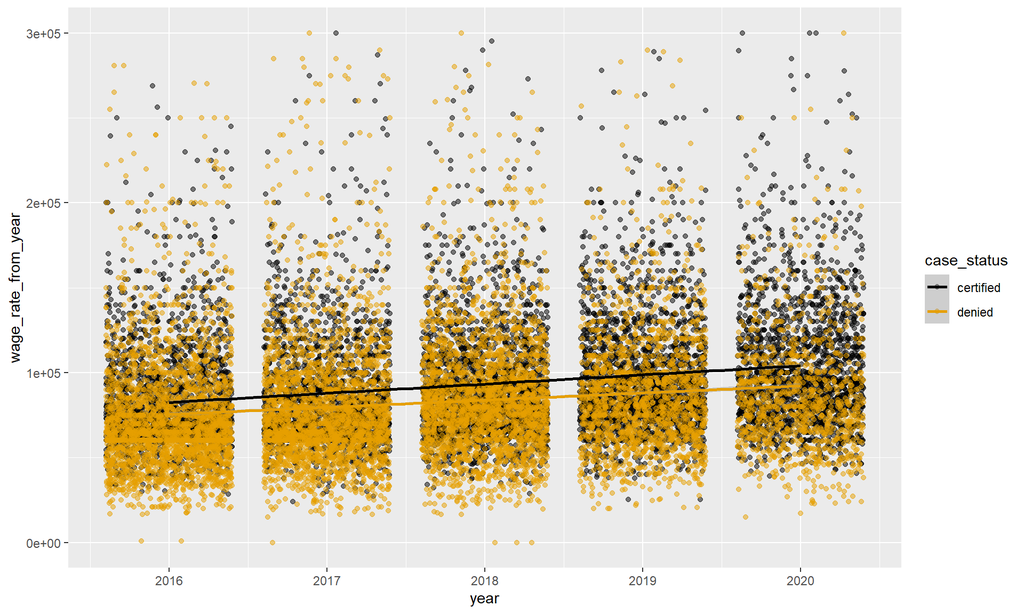

```r
LCA_sample %>%
  ggplot(aes(x = year,
             y = wage_rate_from_year,
             color = case_status)) +
  geom_jitter(alpha = 0.5) +
  geom_smooth(formula = y ~ x, method = "lm") +
  ylim(0, 300000) +
  scale_color_colorblind()
```

### Model 2

> Question: What is the relationship between wage_rate_from_year of denied case_status and state?

```r
denied_case <- LCA_application %>%
  filter(case_status == "denied")

model_prevailing_wage_state <- lm(wage_rate_from_year ~ worksite_state, data = denied_case)

summary(model_prevailing_wage_state)
```

```
##
## Call:
## lm(formula = wage_rate_from_year ~ worksite_state, data = denied_case)
##
## Residuals:
##       Min        1Q    Median        3Q       Max
##  -5511327  -1135114   -863098   -572040 597658513
##
## Coefficients:
##                                              Estimate Std. Error t value
## (Intercept)                                   2590996    1141926   2.269
## worksite_statealaska                         -2501285    3081086  -0.812
## worksite_statearizona                        -1970286    1340640  -1.470
## worksite_statearkansas                       -1243279    1707636  -0.728
## worksite_statecalifornia                     -1651080    1155805  -1.429
## worksite_statecolorado                       -1894242    1374384  -1.378
## worksite_stateconnecticut                     -935434    1387900  -0.674
## worksite_statedelaware                        2950491    1653982   1.784
## worksite_statedistrict of columbia            -563116    1424773  -0.395
## worksite_statefederated states of micronesia -2502646   10181732  -0.246
## worksite_stateflorida                        -2184751    1203064  -1.816
## worksite_stategeorgia                        -1451171    1226826  -1.183
## worksite_stateguam                           -2527355    2586804  -0.977
## worksite_statehawaii                         -2503538    1941801  -1.289
## worksite_stateidaho                          -2501265    2184937  -1.145
## worksite_stateillinois                       -1622351    1205358  -1.346
## worksite_stateindiana                          124140    1397828   0.089
## worksite_stateiowa                           -2464499    1622774  -1.519
## worksite_statekansas                         -2505425    1581528  -1.584
## worksite_statekentucky                       -1191694    1760639  -0.677
## worksite_statelouisiana                      -2495061    1597602  -1.562
## worksite_statemaine                          -2477149    2644025  -0.937
## worksite_statemaryland                       -1121368    1291619  -0.868
## worksite_statemassachusetts                  -1699946    1206131  -1.409
## worksite_statemichigan                       -1148267    1231499  -0.932
## worksite_stateminnesota                      -2492161    1321428  -1.886
## worksite_statemississippi                    -2500389    1982096  -1.261
## worksite_statemissouri                       -1372202    1408600  -0.974
## worksite_statemontana                        -2511439    2359904  -1.064
## worksite_statenebraska                       -2489634    1783880  -1.396
```

[output cut: 75 more lines]

```
## worksite_stateutah                             0.1851
## worksite_statevermont                          0.3652
## worksite_statevirgin islands                   0.4642
## worksite_statevirginia                         0.3206
## worksite_statewashington                       0.1099
## worksite_statewest virginia                    0.2507
## worksite_statewisconsin                        0.6757
## worksite_statewyoming                          0.5333
## ---
## Signif. codes:  0 '***' 0.001 '**' 0.01 '*' 0.05 '.' 0.1 ' ' 1
##
## Residual standard error: 14310000 on 31736 degrees of freedom
##   (31 observations deleted due to missingness)
## Multiple R-squared:  0.001631,   Adjusted R-squared:  -9.94e-05
## F-statistic: 0.9425 on 55 and 31736 DF,  p-value: 0.5961
```

The result (p > 0.05) shows we could not reject null hypothesis, so the denied case wage_rate_from_year have no relationship with state.

### Model 3

> Effect of worksite_state, prevailing_wage_year on wage_rate_from_year of data science related occupations

```r
LCA_ds <- LCA_application %>%
  filter(occupation %in% ds_occupation)

model_ds <- lm(wage_rate_from_year ~ prevailing_wage_year + worksite_state + occupation, data = LCA_ds)

summary(model_ds)
```

```
##
## Call:
## lm(formula = wage_rate_from_year ~ prevailing_wage_year + worksite_state +
##     occupation, data = LCA_ds)
##
## Residuals:
##       Min        1Q    Median        3Q       Max
## -27512607    -81197    -36454      8654 294289283
##
## Coefficients:
##                                      Estimate Std. Error t value Pr(>|t|)
## (Intercept)                         2.767e+04  3.305e+05   0.084 0.933288
## prevailing_wage_year                9.308e-02  7.689e-03  12.105  < 2e-16 ***
## worksite_statearizona              -1.997e+03  3.570e+05  -0.006 0.995537
## worksite_statearkansas             -2.195e+03  3.702e+05  -0.006 0.995269
## worksite_statecalifornia            5.127e+04  3.313e+05   0.155 0.877003
## worksite_statecolorado             -1.089e+03  3.716e+05  -0.003 0.997662
## worksite_stateconnecticut           1.879e+03  3.537e+05   0.005 0.995760
## worksite_statedelaware              7.509e+03  4.055e+05   0.019 0.985228
## worksite_statedistrict of columbia  7.885e+03  3.798e+05   0.021 0.983439
## worksite_stateflorida               2.350e+05  3.457e+05   0.680 0.496587
## worksite_stategeorgia               9.414e+03  3.377e+05   0.028 0.977761
## worksite_stateguam                  4.813e+04  3.062e+06   0.016 0.987457
## worksite_statehawaii                2.228e+04  7.565e+05   0.029 0.976504
## worksite_stateidaho                -1.373e+04  5.016e+05  -0.027 0.978166
## worksite_stateillinois              8.691e+04  3.357e+05   0.259 0.795686
## worksite_stateindiana              -1.242e+04  3.767e+05  -0.033 0.973701
## worksite_stateiowa                  5.970e+03  3.944e+05   0.015 0.987924
## worksite_statekansas               -5.136e+03  4.253e+05  -0.012 0.990364
## worksite_statekentucky             -1.661e+04  4.774e+05  -0.035 0.972239
## worksite_statelouisiana             8.986e+03  5.158e+05   0.017 0.986099
## worksite_statemaine                 1.329e+04  7.564e+05   0.018 0.985979
## worksite_statemaryland              2.113e+04  3.472e+05   0.061 0.951459
## worksite_statemassachusetts         1.029e+05  3.360e+05   0.306 0.759421
## worksite_statemichigan             -7.258e+03  3.449e+05  -0.021 0.983208
## worksite_stateminnesota             1.674e+03  3.497e+05   0.005 0.996180
## worksite_statemississippi          -1.182e+03  1.018e+06  -0.001 0.999073
## worksite_statemissouri             -9.748e+03  3.545e+05  -0.027 0.978066
## worksite_statemontana               3.060e+04  1.401e+06   0.022 0.982572
## worksite_statenebraska             -1.384e+03  4.118e+05  -0.003 0.997317
```

[output cut: 18 more lines]

```
## worksite_statevermont              -2.673e+04  1.286e+06  -0.021 0.983413
## worksite_statevirginia              1.258e+05  3.369e+05   0.373 0.708800
## worksite_statewashington            3.007e+03  3.343e+05   0.009 0.992825
## worksite_statewest virginia         1.879e+04  9.754e+05   0.019 0.984630
## worksite_statewisconsin             1.909e+03  3.744e+05   0.005 0.995932
## worksite_statewyoming               4.646e+03  1.286e+06   0.004 0.997117
## occupationdata engineer             6.362e+04  3.691e+04   1.723 0.084814 .
## occupationdata scientist            1.175e+05  3.395e+04   3.461 0.000539 ***
## occupationmachine learning          4.435e+04  6.274e+04   0.707 0.479676
## ---
## Signif. codes:  0 '***' 0.001 '**' 0.01 '*' 0.05 '.' 0.1 ' ' 1
##
## Residual standard error: 3044000 on 49639 degrees of freedom
## Multiple R-squared:  0.003413,   Adjusted R-squared:  0.002309
## F-statistic: 3.091 on 55 and 49639 DF,  p-value: 1.212e-13
```

The result shows only prevailing_wage_year and date scientist occupation has effects on wage_rate_from_year of data science related occupations

```r
model_ds <- lm(wage_rate_from_year ~ prevailing_wage_year + occupation, data = LCA_ds)

summary(model_ds)
```

```
##
## Call:
## lm(formula = wage_rate_from_year ~ prevailing_wage_year + occupation,
##     data = LCA_ds)
##
## Residuals:
##       Min        1Q    Median        3Q       Max
## -27500520    -75443    -31069     -9322 294291708
##
## Coefficients:
##                             Estimate Std. Error t value Pr(>|t|)
## (Intercept)                8.135e+04  2.277e+04   3.572 0.000354 ***
## prevailing_wage_year       9.305e-02  7.685e-03  12.108  < 2e-16 ***
## occupationdata engineer    5.674e+04  3.581e+04   1.584 0.113107
## occupationdata scientist   1.127e+05  3.268e+04   3.447 0.000568 ***
## occupationmachine learning 4.259e+04  6.104e+04   0.698 0.485301
## ---
## Signif. codes:  0 '***' 0.001 '**' 0.01 '*' 0.05 '.' 0.1 ' ' 1
##
## Residual standard error: 3042000 on 49690 degrees of freedom
## Multiple R-squared:  0.003192,   Adjusted R-squared:  0.003111
## F-statistic: 39.77 on 4 and 49690 DF,  p-value: < 2.2e-16
```

The output shows there is a positive relationship between prevailing_wage_year and wage_rate_from_year of data science related occupations. Data scientist occupation also has a positive relationship.

Let’s visualize.

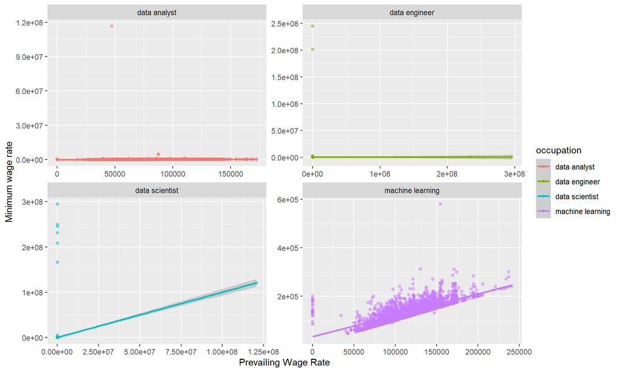

```r
LCA_ds %>%
  ggplot(aes(x = prevailing_wage_year,
             y = wage_rate_from_year,
             color = occupation)) +
  geom_jitter(alpha = .5) +
  facet_wrap(~occupation, scales = "free") +
  geom_smooth(method = "lm") +
  labs(x = "Prevailing Wage Rate",
       y = "Minimum wage rate")
```

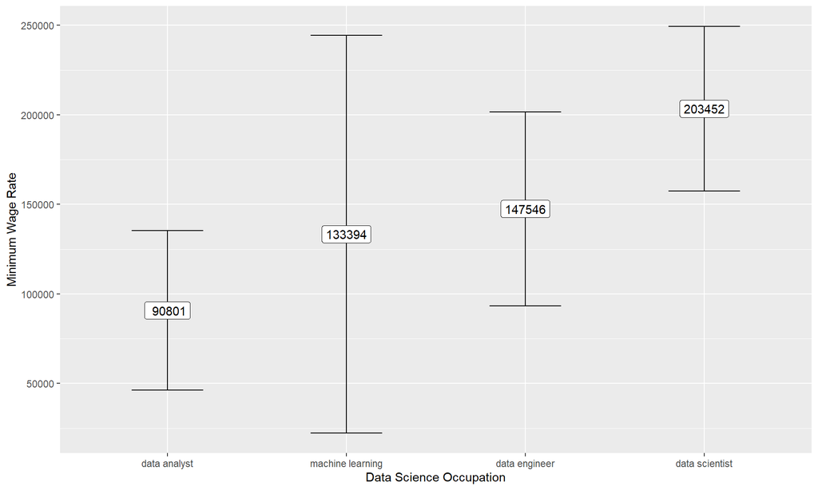

```r
effect("occupation", model_ds) %>%
  data.frame() %>%
  ggplot(aes(x = reorder(occupation, fit),
             y = fit,
             ymin = lower,
             ymax = upper,
             label = format(fit, digits = 2))) +
  geom_errorbar(width = .4) +
  geom_label() +
  labs(x = "Data Science Occupation",
       y = "Minimum Wage Rate")
```

As we can see above, the data scientist and machine learning positions’ minimum paid wages keep increasing as the increment of the prevailing wage but the data analyst and data engineer don’t. In addition, the machine learning position has the most variances. The possible reasons for this results is the USCIS doesn’t consider the position levels as a factor in the LCA applications. Even for the same position title, the wage rates are different based on the positions levels. If we sum the data science related job amount, we would notice they are just a tiny port of LCA applications, 50k out of 3M. In another words, the US companies are not likely to hire foreign workers for Data science positions.